# 横断的ネットワーク解析：基礎編

TWS-007「心理ネットワークアプローチ入門」

国里愛彦（専修大学）

日本心理学会(2022年)

## 心理ネットワークとは？

心理ネットワークは，観察可能な変数を表すノードと統計的関係を表すエッジから構成される(Epskamp, Borsboom & Fried, 2018)。心理ネットワークモデルは，因子分析やSEMなどのように潜在変数を仮定してそれから各項目・症状を説明するのではなく，症状（心理変数）間のネットワーク構造を検討する。

心理ネットワークは，以下の図のように，観察可能な変数を表すノードは円で，関係を表すエッジは線でプロットされる。

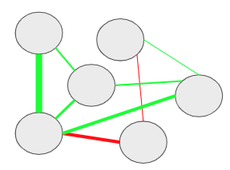

### 心理ネットワーク分析の手順

基本的な心理ネットワーク分析は，おおよそ以下の４ステップからなる。

1. 統計的手法によってノード間のエッジを推定する
2. 推定された統計的関係をもとにネットワークを図示する
3. ネットワーク特性の指標の検討する
4. ネットワークの精度の検討する

ここで注意すべき点は，一般的なネットワーク科学で扱うネットワークの場合は，エッジは観察可能な点である（例えば，電力網ネットワークのエッジは直接観察・測定可能です）。しかし，心理ネットワークのエッジは，データから推定される（重み付きネットワーク）。そのため，サンプルサイズの影響も受けるので，ネットワークのエッジの精度も検討する必要がある。また，一般的なネットワーク科学では，グローバルなネットワーク特性の指標が使われる(small worldness, density, global clustering)。しかし，心理ネットワークのような重み付けネットワークではこれらは使えない。そのため，２つのノードの関係や１つのノードがどのような影響力をもつのか（中心性の指標）といったローカルなネットワーク特性を用いる。

### 有向・無向ネットワーク

心理ネットワークの話の前に，有向ネットワークと無向ネットワークについて説明する。まず，有向ネットワークとはエッジに方向性があるネットワークになる。以下の図ようにエッジが矢印になっているネットワークが有向ネットワークである。この矢印の方向には因果関係が想定される。例えば，「活動性低下→抑うつ気分増加」なら，活動低下が原因となって抑うつ気分増加するという意味になる。ただし，「活動性低下→抑うつ気分増加」と聞いて，「活動性低下←抑うつ気分増加」もありえるのではないかと感じた方もおられるかもしれない。そのとおりで，因果関係を言うには，まず原因は結果に時間的に先行する必要があり，因果に関連する変数が全て測定された上で，原因と結果が巡回しない（非巡回）必要がある。観察研究によって収集された心理学のデータの場合，時間的な前後関係は縦断データによって示せても，非巡回となるとかなり難しい。そのため，横断データに対する心理ネットワークでは，エッジに方向性がない無向ネットワークが用いられる。

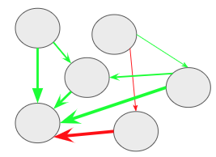

### ２つのノードの関係(エッジの符号)

横断データに対する心理ネットワークでは，エッジに方向性がない無向ネットワークが用いられる。エッジの色は符号を意味していて，青もしくは緑の場合は正，赤の場合は負を表す。エッジが正（青色もしくは緑色）の場合は，２つのノード間には正の関係性が存在する（片方が増えると，もう一方も増える）。エッジが負（赤色）の場合は，２つのノード間には負の関係性が存在する（片方が増えると，もう一方は減る）。また，エッジの太さは，関係の強さを表す。この場合の関係の強さとは，全体のノードからの影響を考慮した時の２つのノード間の関係の強さになる。そして，エッジの長さは，エッジの強さの逆数になる。つまり，ノード間の関係が強ければ強いほど，エッジは短くなる。

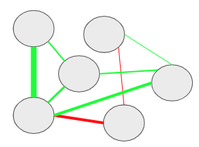

## pairwise Markov random field (PMRF：ペアワイズマルコフ確率場)

変数間の関係がある・ないというグラフを作る場合に，確率分布と結びつけるようなモデルのことをペアワイズ・マルコフ・グラフ(pairwise Markov graph)と呼ぶ。そして，心理ネットワークで用いる無向ネットワークモデルの推定では，ペアワイズ・マルコフ確率場(pairwise Markov random field: PMRF)がよく使われる(Isvoranu, Epskamp, Waldorp & Borsboom, 2022)。心理ネットワーク分析で用いられるPMRFは，基本的に重み付きネットワークである。PMRFでは，ネットワークのエッジは，他のすべてのノードの影響を除外したあとでの２つのノード間の条件付き関連になります。つまり，２つのノード間にエッジがあるということは，条件付き依存(conditionally dependent)関係にあることを表し，一方でエッジがない場合は，条件付き独立(conditionally independent)関係にあることを表す。

ペアワイズマルコフ確率場には様々なモデルがあるが，心理ネットワーク分析においては，以下の３つのモデルがよく用いられる。

1. Gaussian graphical model (GGM): 連続変数のデータ
2. Ising model: 2値変数のデータ
3. mixed graphical models (MGMs): 2値変数と連続変数の混ざったデータ

３モデルとも，エッジは条件付き関連の強さを表現しており，0では条件付き独立，0以外だと条件付き依存関係になる。GGMではエッジは-1から1の範囲で値をとる。Isingモデルではエッジは-∞から∞の範囲で値をとる。MGMではGLMの標準化された回帰係数を用いており，エッジは-1から1の範囲で値をとる。

### Gaussian graphical model

データが連続かつ正規分布の場合には，多変量正規分布を用いたGaussian Graphical Model(GGM)が用いられる。心理学で収集するデータは，連続変数かつ正規分布を仮定できることも多いので，心理ネットワーク分析ではGGMがよく用いられます。

GGMでは，変数間の関係を偏相関係数によってモデル化します。**Y**は，ランダムに選んだ参加者からのn個の反応のベクトルであり，**y**はその実現値である。**Y**には平均 $\boldsymbol{\mu}$ と分散共分散行列 $\boldsymbol{\sum}$ の正規分布を仮定する。

$$\boldsymbol{Y} \sim N\left(\boldsymbol{\mu}, \boldsymbol{\sum}\right)$$

そして，正規分布なので，尤度関数は以下のようになります。

$$f(\boldsymbol{Y}=\boldsymbol{y})=\frac{1}{\sqrt{(2
\pi)^{n}\left|\boldsymbol{\sum}\right|}} \exp
\left(-\frac{1}{2}(\boldsymbol{y}-\boldsymbol{\mu})^{\mathrm{T}}
\boldsymbol{\sum}^{-1}(\boldsymbol{y}-\boldsymbol{\mu})\right)$$

データの中心化（値から平均値を引く)を行うと，以下のように，**Y**の実現値の$\mathbf{y_{c}}$は，平均0, 分散共分散行列 $\mathbf{\Sigma}$ の多変量正規分布に従います。

$$\mathbf{y_{c}} \sim N(\mathbf{0}, \mathbf{\Sigma})$$
$\mathbf{y_{c}}$ のcはcaseつまりデータフレームの行に対応しています（例. y[c=1,1]は１人目の不安得点，y[c=2,1]は2人目の不安得点, y[c=1,2]は１人目のうつ得点など）。そして，分散共分散行列 $\mathbf{\Sigma}$は，ベクトル**y**に含まれる変数間の分散共分散行列になります。

#### 分散共分散行列→精度行列→偏相関行列

GGMでの偏相関行列を算出する際に，分散共分散行列 $\boldsymbol{\sum}$ が重要です。GGMでは， $\boldsymbol{\sum}$ を直接的に扱わずに，その逆数である $\boldsymbol{K}$ の標準化した要素を扱います。 具体的な手続きとしては，分散共分散行列からその逆行列である精度行列を計算し，精度行列から偏相関行列を計算します。なんだかややこしそうですが，そうでもありません。

まず，Kは精度行列です。この精度行列Kは，分散共分散行列の逆行列になります。

$$\boldsymbol{K}=\boldsymbol{\Sigma}^{-1}$$

逆行列って何？ってなるかもしれないのですが，逆行列は，ｎ次正方行列Aに掛けた場合に以下のような単位行列Eとなるような行列のことです。分散共分散行列に何か行列をかけ合わせた時に，以下のような単位行列Eになるようなものがここで知りたい逆行列です。どうやって逆行列計算するの？って思われたかもしれませんが，以降はパソコンに頼ってRで計算させつつ分散共分散行列から精度行列を経由して，偏相関行列を計算してみましょう。

$$\boldsymbol{E}=\left[\begin{array}{lcc}1
& 0 \\ 0 & 1\end{array}\right]$$
以降の計算は，Epskamp, Waldorp, Mõttus & Borsboom(2018)に記載されている例を用います。まず，以下のような分散共分散行列( $\mathbf{\Sigma}$ ) Aを使って，これを偏相関行列にします。Aは以下の通りです。Rで計算できますので，以下をコピペして実行ください。変数１と変数２は負の関連があり，変数１と変数３は正の関連があり，変数２と変数３は関連は弱そうです。

```r
A <- matrix(c(1,-0.26,0.31,-0.26,1,-0.08,0.31,-0.08,1), 3, 3)
A
```

```
##       [,1]  [,2]  [,3]
## [1,]  1.00 -0.26  0.31
## [2,] -0.26  1.00 -0.08
## [3,]  0.31 -0.08  1.00
```

さて，この分散共分散行列Aの逆行列，つまりAの精度行列を計算しましょう。手計算だと大変なので，ここはサクッとRのsolve()関数に計算させます。以下を実行ください。精度行列では，一部符号が逆転していますね（必ずではないです）。逆行列の計算では，特定の変数間の関連について他の変数の影響も考慮することになります。そのため，この精度行列（分散共分散行列の逆行列）を使って，偏相関行列を求めることができます。なお，逆行列が存在する行列は正則行列と呼ばれます。

```r
inv_A <- solve(A)
inv_A
```

```
##            [,1]          [,2]          [,3]
## [1,]  1.1789330  0.2790710919 -0.3431435365
## [2,]  0.2790711  1.0725015306 -0.0007119161
## [3,] -0.3431435 -0.0007119161  1.1063175430
```

以下の式を使って，上記で算出した精度行列から偏相関係数を求めることができます。

$$\operatorname{Cor}\left(Y_{i}, Y_{j}
\mid \boldsymbol{y}_{-(i, j)}\right)=-\frac{\kappa_{i
j}}{\sqrt{\kappa_{i i}} \sqrt{\kappa_{j j}}}$$
これは手計算でも簡単にできるのですが，現代人なので，Rのstatsパッケージのcov2cor関数を使って偏相関行列を計算をしちゃいましょう。あまり大きな変化はないかもしれませんが，変数２と３の関係が分散共分散行列行列よりも小さくなり，関係がないと言ってもよいかと思われます。この偏相関行列の偏相関係数をエッジにしてネットワークを描きます。

```r
library(stats)
-1 * cov2cor(inv_A)
```

```
##            [,1]          [,2]          [,3]
## [1,] -1.0000000 -0.2481826016  0.3004632529
## [2,] -0.2481826 -1.0000000000  0.0006535667
## [3,]  0.3004633  0.0006535667 -1.0000000000
```

GGMは比較的シンプルなものです。多変量正規分布の分散共分散行列から偏相関行列を計算して，それを用いてネットワークを書くというものです。

#### クロスセクショナルデータのGGM

GGMは上記で説明をしたように，推定は簡単なので，最尤推定，最小二乗法，ベイズどれを使っても良いです。ただし，精度行列を求める方法としては，分散共分散行列の逆行列の計算でもできるけど，ネットワークのエッジが多すぎるとネットワークの理解がしにくくなります。そのため，ネットワークを疎(sparse)にするような手法が用いられることが多いです。そのような手法の１つとして，正則化(regularization)があります。正則化は，機械学習などにおいて発展してきた手法で，モデルの複雑さに罰則をかけて，過学習を避けるような手法です。ざっくり説明すると，多数の変数を使って予測をする場合に，影響力が弱い変数の影響をゼロに近づけるような工夫を導入することで，不要なエッジを除くことができる。影響力は弱いけそ存在している変数が減るとモデルが複雑じゃなくなりますが，複雑さに罰則をかけると，影響力は弱いけそ存在している変数の影響をゼロに近づけるようになります。このようにして，解釈に置いて煩雑なエッジを減らすことができます。GGMでは，LASSO(least absokute shrinkage and selection operator)が使われます。特にLASSOの一種のGraphical LASSOは，精度行列に直接的に罰則をかけられ，分散共分散行列があれば計算でき，一般的に他の方法よりも早いです。そして，このGLASSOのパラメータ調整では，EBICを使うのが推奨されています。

## 要修正と加筆

#### GGMの解釈法

GGMで計算されるエッジはどのように解釈されるでしょうか？まず，偏相関になりますので，通常の２変数間の相関係数ではなく，２変数以外の影響も考慮した２変数の関係になります。なので，ネットワークに含まれる変数の違いによっては，値が異なる可能性もありますし，２変数だけでなくネットワーク全体を考慮した解釈が必要になります。その際の解釈としては，つい「変数Aによって変数Bが引き起こされた」のような因果に踏み込んだ解釈をしてしまいますが，横断データのGGMで得られたエッジからそのような方向性をもった解釈は難しいです。できる解釈としては，(1)予測可能性の示唆と(2)因果関係の示唆になります。まず，因果関係は不明ではありますが，他の変数の影響を考慮しても，ある変数から別の変数が予測できているとはいえるので，A-B-Cという形でエッジがある場合に，BはAかCを予測する可能性があります。もちろん，最終的には縦断調査によって予測ができるかどうか検証する必要はあります。次に，因果関係の仮定を満たすことはできないし，効果の方向性は不明だが，そのエッジにはなんらかの因果的な効果がある可能性はあります。この結果を踏まえて，より因果関係に踏み込めるような研究を行うことができると思います。どちらも歯に物が挟まったような表現ですが，多くの場合心理ネットワークは探索的に実施されることからも，強い理論的予測による仮説検証の結果のような解釈をしないように気をつける必要があります。

### Ising モデル

Isingモデルは，磁石などの磁性体に関する統計力学的モデルです。２値をとるネットワークの記述に使えるのと，相転移などの現象も扱えるので，心理ネットワーク分析では用いられます（心理学における項目反応理論との類似も指摘されています）。Isingモデルは２値反応の組の同時確率をモデル化しており，同時確率分布は以下になります(Isvoranu et al.,2022) 。

$$\operatorname{Pr}(\boldsymbol{Y}=\boldsymbol{y})=\frac{1}{z} \exp
\left(\sum_{i} y_{i} \tau_{i}+\sum_{<i, j>} y_{i} y_{j} \omega_{i
j}\right)%$$

**Y**はランダムな参加者の２値反応のベクトルであり，**ｙ**はある参加者の２値反応のベクトルです（確率変数の実現値）。τは，閾値であり，２値反応のどちらにいきやすいかです。ωは，ネットワークパラメータであり，ノード間の反応の類似度です。Zは，分割関数(partition function)であり，確率の合計が１になるようにな機能を担っています。Zは以下のように計算できます。

$$Z=\sum_{y} \exp \left(\sum_{i} y_{i} \tau_{i}+\sum_{<i, j>} y_{i}
y_{j} \omega_{i j}\right)$$

このZの計算はすべてのYの可能性のあるアウトカムの合計と考えます。なので計算は大変であり，20変数以上の多変量推定は難しいです。その場合は，単変量推定にして，単純化して推定します。なお，Isingモデルには逆温度(β)も含まれますが，パメータ推定の際には１に固定しています。 Isingモデルは，Epskamp, Maris, Waldorp & Borsboom(2018)に詳しいです。

## Mixed graphical models

MGMsは，連続，カウント，カテゴリカルデータのような異なるデータを用いてネットワークを作ることができます(Isvoranu et al., 2022)。データのタイプが異なるので，それぞれのノードは異なる確率分布が関係しますが，どれも指数分布族(正規分布，ポワソン分布，指数分布，多項分布）に含まれる分布です。

MGMsは，ｎ個の単変量で条件付きの指数分布族を同時分布に因子分解することで作られます。nはノードの番号， $\boldsymbol{Y}_{\backslash i}$ は，ノードi以外のノードのセットです。

$$P_{P L}(\boldsymbol{Y}=\boldsymbol{y})=\prod_{i-1}^{n} P\left(Y_{i} \mid
\boldsymbol{Y}_{\backslash i}\right)$$

GGMもIsingモデルも指数分布族を使って因子分解しているので，MGMsの特殊なケースといえます。  
MGMsは，ノードごとの回帰分析によって推定し（ノードごとの条件つき分布が推定される），すべての推定されたパラメータが最終モデルで統合されます。

MGMsは，ペアワイズである必要もなくて，高次の相互作用を含めたmoderated network modelも検討できます。

### ノードの中心性指標

心理ネットワークは，重み付けネットワークのため，その他のネットワークと違って，グローバルなネットワーク特性の指標（small worldness, density, global clustering）が使えません。そこで，各ノードの他のノードの影響性のようなローカルなネットワーク特性（中心性指標）を用います。そのようなローカルなネットワーク特性としては，strength，closeness，betweenessの３つがあります。

**Strength**

Strength（重み付けのないネットワークの場合は，degreeと言う）は，あるノードがつながっている全てのエッジの強さを合計したものです。あるノードが他のノードとどのくらい強くつながっているのかを表す指標であり，そのノードの全体に対する影響力を表しているといえます。

**Closeness**

Closenessは，あるノードと他の全てのノード間の最短経路長の合計の逆数になります。なにそれ？と思ったかもしれません。まず，ノード間の最短経路長とは，あるノードから別のノードまで最短距離でいける距離です。この距離というのは，エッジの強さの逆数になります。つまり，エッジの強さが0.1ならばその逆数は1/0.1で10になり，エッジの強さが0.5ならば1/0.5で2になります。最短経路長は，この距離を使って，あるノードから別のノードまでの距離を計算して，最も短い距離でいける距離を計算します。そして，あるノードへの他の全てのノードとの最短経路長を計算して，合計したものの逆数がClosenessになります。

このような感じで，あるノードから他のノードまでの最短経路長をそれぞれ計算していって，それらを合計したものの逆数がClosenessになります。Closenessは，あるノードがどのくらい間接的な影響を含めて他のノードとつながっているのかを示しています(一方，Strengthは，あるノードがどのくらい直説的に他のノードとつながっているのかを示しています）。つまり，あるノードから他のノードへの拡散の速さを表現していると言えます。

**Betweeness**

### ネットワークの正確度(accurary)

エッジは統計的に推定されるものなのでサンプルサイズの影響をうけます。ノードが増えると推定するパラメータはどんどん増えるので一般的な心理学研究では，サンプルサイズが足りないこともあります。そのため，ネットワークの正確度についても検討しておく必要があります（ネットワークの正確度については，Epskamp, Borsboom,& Fried (2018)に詳しいです）。

エッジの重みと中心性指標の精度の検証方法は，以下の３ステップになります(Epskamp, Borsboom,& Fried, 2018)。

1. ブートストラップされた信頼区間をプロットすることでエッジの重みの正確度を検討する。
2. データのサブセットを用いた場合の中心性指標の安定性(Stability)を検討する。
3. エッジの重みと中心性指標間でブートストラップ差異検定行って，それらが有意に異なるのかを検討する。

心理ネットワーク分析を用いた際には１は必ず実施しますが，２と３については中心性に関心があるか差異検定に関心があるかによって実施を検討します。詳しくは，以降のRでの心理ネットワーク分析で触れます。

### Rパッケージ

偏相関行列の計算自体は複数のRパッケージで可能になりますので，心理ネットワーク分析に使えるRパッケージは複数あります。ただし，心理ネットワーク分析の中心地でもあるアムステルダム大学の[Sacha Epskamp](http://sachaepskamp.com/)が開発した[qgraph](https://cran.r-project.org/web/packages/qgraph/index.html)と[bootnet](https://cran.r-project.org/web/packages/bootnet/index.html)と[psychonetrics](https://cran.r-project.org/web/packages/psychonetrics/index.html)があれば，横断データの心理ネットワーク分析は実施できます。

- [qgraph](https://cran.r-project.org/web/packages/qgraph/index.html):ネットワークのプロットと推定
- [bootnet](https://cran.r-project.org/web/packages/bootnet/index.html): 様々な種類のネットワーク推定，ネットワークの正確度の検討
- [psychonetrics](https://cran.r-project.org/web/packages/psychonetrics/index.html)：より洗練化した書き方でネットワーク分析ができるパッケージ

なお，アムステルダム大学で開発しているベイズ統計と頻度論統計のGUIソフトウェアである[JASP](https://jasp-stats.org/)には，心理ネットワーク分析が組み込まれており，簡単に実施して見る上ではかなり有用と思います。JASPは国里を含む日本語化チームにより2021年9月(v0.15)より一部が日本語化されています。心理ネットワーク分析の説明は，[こちら](https://jasp-stats.org/2018/03/20/perform-network-analysis-jasp/)をご確認ください。

## 心理ネットワーク分析を試してみよう！

さて，以下では，実際にRで心理ネットワーク分析を実行してみましょう。その題材として， [Jordan, P., Shedden-Mora, M. C., & Löwe, B. (2017). Psychometric analysis of the Generalized Anxiety Disorder scale (GAD-7) in primary care using modern item response theory. PloS One, 12(8), e0182162.](https://journals.plos.org/plosone/article?id=10.1371/journal.pone.0182162)を選びました。この研究は，不安の症状評価で用いられるGAD-7について項目反応理論を用いた検討を行った研究です。Hamburgのプライマリケアを受診した3404名からGAD-7(全般性不安)，PHQ-9(うつ),PHQ-15(身体症状)データを収集しており，比較的サンプルサイズが大きいのと，雑誌のサイト上でデータを公開していることから，以下の心理ネットワーク分析の練習で使ってみましょう。

### 使用するRパッケージの読み込み

Jordan et al.(2017)のデータがSPSS形式で配布されているのでSPSS形式のデータを読み込むforeignパッケージとデータ処理用にtidyverseパッケージを読み込みます。そして，心理ネットワーク分析では，上述したbootnetパッケージとqgraphパッケージを読み込みます。

```r
library(tidyverse)
library(foreign)
library(bootnet)
library(qgraph)
library(psychonetrics)
```

### データの読み込み

Jordan et al.(2017)のデータを雑誌のサイトからdownload.fileでダウンロードして，それを読み込みます。

```r
download.file("https://doi.org/10.1371/journal.pone.0182162.s004","pone.0182162.s004.sav")
data <- read.spss("pone.0182162.s004.sav",
                  to.data.frame=TRUE)
```

変数名がややこしかったので，renameで名前を変更しています。

```r
# データの整理
data_gad <- data %>%
  rename(gad7a = S_GAD7_a, gad7b = S_GAD7_b,
         gad7c = S_GAD7_c, gad7d = S_GAD7_d,
         gad7e = S_GAD7_e, gad7f = S_GAD7_f,
         gad7g = S_GAD7_g) %>%
  select(gad7a, gad7b, gad7c, gad7d, gad7e, gad7f, gad7g)
```

### ネットワークの推定とプロット

早速，エッジの推定をしましょう。bootnetパッケージのestimateNetwork()関数を使います。エッジの推定にあたり，EBICでモデル選択して，パラメータ調整をするGLASSOを使います(defaultで”EBICglasso”を指定する）。GAD-7は，不安症状について，「まったくない」から「ほとんど毎日」の４件法で頻度を問います。これは，順序変数と考えられるので，通常の分散共分散ではなくて，ポリコリック相関（順序変数の相関）を計算します。corMethodで “cor_auto”を指定すれば，自動的に順序変数にはポリコリック相関を計算してエッジの推定をしてくれます（なお，“cor_auto”では７件法以下は順序変数として扱います）。

```r
results_gad <- estimateNetwork(data_gad,default = "EBICglasso", corMethod = "cor_auto")
```

推定したエッジをネットワークとしてプロットしてみましょう（layoutは”spring”を指定します）

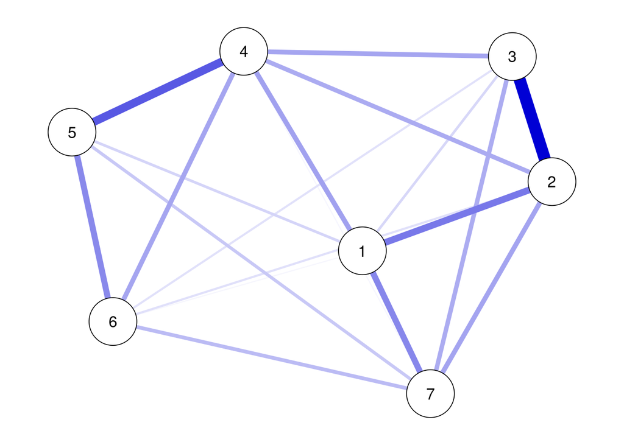

```r
plot(results_gad, theme = "colorblind", cut = 0,layout = "spring",labels = TRUE)
```

#### Psychonetricsを使う

Psychonetricsパッケージも[Sacha Epskamp](http://sachaepskamp.com/)が開発したパッケージであり，qgraphやbootnetと連携しつつネットワークの推定をします。Psychonetricsは複数モデルを扱えたり（ggmとIsingモデルが扱える），パイプ演算子が使えやすい書き方ができるので，Tidyverseに慣れていると便利と思います。

書き方は以下のように，最初に使用するモデルにデータをいれて，パイプ演算子でrunmodelに送って推定し，getmatrixでエッジの情報を得て，プロットする感じです。

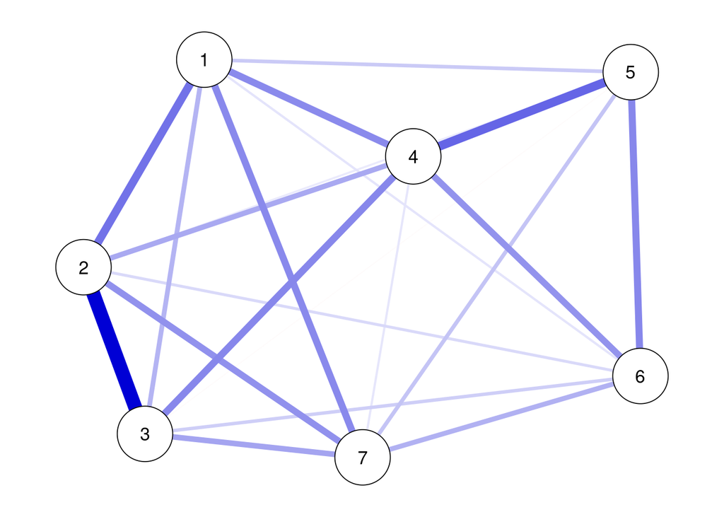

```r
library(psychonetrics)
ggm(data_gad) %>%
  runmodel %>%
  getmatrix("omega") %>%
  qgraph(theme = "colorblind", cut = 0,layout = "spring",labels = TRUE)
```

推定したパラメータを確認したい場合は，以下のように書けます。

```r
library(psychonetrics)
ggm(data_gad) %>%
  runmodel %>%
  parameters
```

```
##
##  Parameters for group fullsample
##  -  mu
##   var1 op var2  est    se        p row col par
##  gad7a ~1      0.80 0.016 < 0.0001   1   1   1
##  gad7b ~1      0.59 0.015 < 0.0001   2   1   2
##  gad7c ~1      0.76 0.016 < 0.0001   3   1   3
##  gad7d ~1      0.90 0.017 < 0.0001   4   1   4
##  gad7e ~1      0.46 0.014 < 0.0001   5   1   5
##  gad7f ~1      0.74 0.014 < 0.0001   6   1   6
##  gad7g ~1      0.51 0.014 < 0.0001   7   1   7
##
##  -  omega (symmetric)
##   var1 op  var2     est    se        p row col par
##  gad7b -- gad7a    0.23 0.016 < 0.0001   2   1   8
##  gad7c -- gad7a    0.12 0.017 < 0.0001   3   1   9
##  gad7d -- gad7a    0.19 0.017 < 0.0001   4   1  10
##  gad7e -- gad7a   0.088 0.017 < 0.0001   5   1  11
##  gad7f -- gad7a   0.045 0.017   0.0095   6   1  12
##  gad7g -- gad7a    0.20 0.017 < 0.0001   7   1  13
##  gad7c -- gad7b    0.42 0.014 < 0.0001   3   2  14
##  gad7d -- gad7b    0.14 0.017 < 0.0001   4   2  15
##  gad7e -- gad7b   0.034 0.017    0.050   5   2  16
##  gad7f -- gad7b   0.063 0.017  0.00030   6   2  17
##  gad7g -- gad7b    0.18 0.017 < 0.0001   7   2  18
##  gad7d -- gad7c    0.20 0.017 < 0.0001   4   3  19
##  gad7e -- gad7c -0.0058 0.017     0.74   5   3  20
##  gad7f -- gad7c   0.080 0.017 < 0.0001   6   3  21
##  gad7g -- gad7c    0.15 0.017 < 0.0001   7   3  22
##  gad7e -- gad7d    0.25 0.016 < 0.0001   5   4  23
##  gad7f -- gad7d    0.18 0.017 < 0.0001   6   4  24
##  gad7g -- gad7d   0.042 0.017    0.016   7   4  25
##  gad7f -- gad7e    0.20 0.017 < 0.0001   6   5  26
##  gad7g -- gad7e   0.098 0.017 < 0.0001   7   5  27
##  gad7g -- gad7f    0.13 0.017 < 0.0001   7   6  28
##
##  -  delta (diagonal)
##   var1  op  var2  est     se        p row col par
##  gad7a ~/~ gad7a 0.62 0.0076 < 0.0001   1   1  29
##  gad7b ~/~ gad7b 0.50 0.0062 < 0.0001   2   2  30
##  gad7c ~/~ gad7c 0.56 0.0069 < 0.0001   3   3  31
##  gad7d ~/~ gad7d 0.63 0.0077 < 0.0001   4   4  32
##  gad7e ~/~ gad7e 0.62 0.0076 < 0.0001   5   5  33
##  gad7f ~/~ gad7f 0.64 0.0079 < 0.0001   6   6  34
##  gad7g ~/~ gad7g 0.58 0.0071 < 0.0001   7   7  35
```

## 要修正と加筆

### エッジの重みの正確度

エッジの重みの正確度を評価する方法として，95%信頼区間を使う方法があります。その際に，ブートストラップ法を用いる。ブートストラップ法は，データ元から復元抽出（無作為に取り出したデータを戻してから取り出すことを繰り返すこと，つまり同じデータを取り出すことがある）を繰り返して，何度も取り出したデータから推定値を計算して，誤差などの性質を明らかにする方法です。95%信頼区間もブートストラップ法を用いて計算できます。

ブートストラップ法には，ノンパラメトリックとパラメトリックがあります。ノンパラメトリックブートストラップは常に使えますが，パラメトリックブートストラップはデータのパラメトリックモデルがある場合のみ使用できます。基本的にはノンパラメトリックブートストラップを使います。正則化されてない，ノンパラメトリックでは結果が不安定である，ノンパラとパラメトリックで比較したい場合のみパラメトリックブートストラップを使います。

ちなみに，ブートストラップで推定した95%信頼区間は，０をまたぐかどうかで有意性の確認にも使えますが，心理ネットワークモデルの場合は正則化されているので，避けるほうが良い。あくまで，エッジの重みの正確度を調べるために使いましょう。

```r
accuracy_edge <- bootnet(results_gad, nBoots = 2500, nCores =4, statistics =   c("edge", "strength", "closeness", "betweenness"))
```

summaryで推定結果を確認できます。ただ，以下のプロットのほうが確認がしやすいです。

```r
summary(accuracy_edge)
```

```
## # A tibble: 42 × 17
## # Groups:   type, node1, node2 [42]
##    type  id    node1 node2  sample   mean      sd CIlower CIupper   q2.5   q97.5
##    <chr> <chr> <chr> <chr>   <dbl>  <dbl>   <dbl>   <dbl>   <dbl>  <dbl>   <dbl>
##  1 betw… gad7a gad7a ""     2      1.5    1.17    -0.337   4.34   0       4
##  2 betw… gad7b gad7b ""     2      3.16   1.90    -1.79    5.79   2       8
##  3 betw… gad7c gad7c ""     0      1.62   2.32    -4.64    4.64   0       8
##  4 betw… gad7d gad7d ""    12      9.39   2.23     7.55   16.5    4      12
##  5 betw… gad7e gad7e ""     0      1.03   1.92    -3.83    3.83   0       6
##  6 betw… gad7f gad7f ""     0      0.375  0.809   -1.62    1.62   0       2
##  7 betw… gad7g gad7g ""     0      1.11   1.62    -3.23    3.23   0       6
##  8 clos… gad7a gad7a ""     0.0257 0.0257 0.00146  0.0228  0.0286 0.0228  0.0286
##  9 clos… gad7b gad7b ""     0.0260 0.0264 0.00155  0.0229  0.0291 0.0236  0.0296
## 10 clos… gad7c gad7c ""     0.0252 0.0257 0.00168  0.0218  0.0285 0.0224  0.0290
## # … with 32 more rows, and 6 more variables: q2.5_non0 <dbl>, mean_non0 <dbl>,
## #   q97.5_non0 <dbl>, var_non0 <dbl>, sd_non0 <dbl>, prop0 <dbl>
## # ℹ Use `print(n = ...)` to see more rows, and `colnames()` to see all variable names
```

それでは，プロットしてみましょう。サンプルサイズが大きいためか，95%信頼区間の幅が狭いですね。

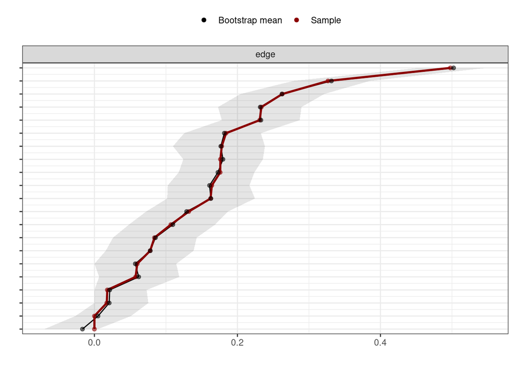

```r
plot(accuracy_edge, labels = FALSE, order = "sample")
```

### 中心性の指標のプロット

中心性の指標は，qgraphパッケージのcontralityPlot関数でプロットできます。中心性指標は複数あるので，includeで”Strength”, “Betweenness”, “Closeness”の３つを指定します。

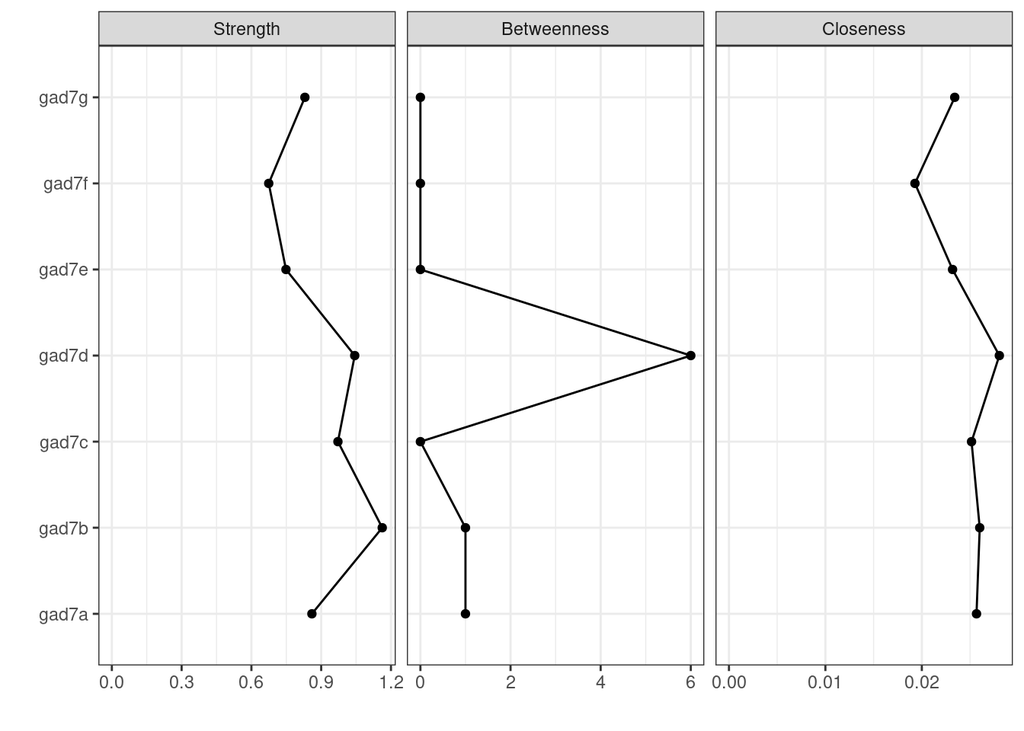

```r
centralityPlot(results_gad, include = c("Strength", "Betweenness", "Closeness"))
```

### 中心性指標の安定性(Stability)

中心性指標の正確度の解釈ができるように，データのサブセットを用いて，中心性指標の順序がどのくらい安定しているか検討します。具体的には，参加者を減らしていった場合（ケースドロップ）もしくはノードを減らしていった場合（ノードドロップ）にどのくらい中心性指標の順序が安定しているかを検討します。ノードドロップは解釈が難しくなるので（ノードをへらすと別のネットワークになるのは当然なので評価しにくい），ケースドロップを使用するのが良いかと思います。

中心性指標の安定性は，CS係数(correlation stability coefficient)によって評価します。CSはドロップできるケースの最大比率を表現しています。具体的には，参加者数を減らしていった場合に，元の中心性指標とドロップした中心性指標間に0.7以上の相関がブートストラップしたサンプルの95%にあるような最大のドロップケース比率である。多少恣意的な基準にはなるが，中心性の解釈をする上では，CS係数が0.25未満は不適切であり，できればCS係数は0.5を越えている必要がある(Epskamp, Borsboom, & Fried, 2018)。

中心性指標の安定性は，エッジの重みの正確度と同様にbootnetを使います。typeで”case”を指定するとケースドロップ時の安定性を推定します。なお，中心性の指標は複数あるので，statisticsで”strength”, “closeness”, “betweenness”を指定します。なお，国里のゼミ生でサーバーを使っている人は，コアは１つで実行してください。

```r
stability_centrality <- bootnet(results_gad, nBoots = 2500, type = "case", nCores =4, statistics =  c("strength", "closeness", "betweenness"))
```

プロットして確認します。

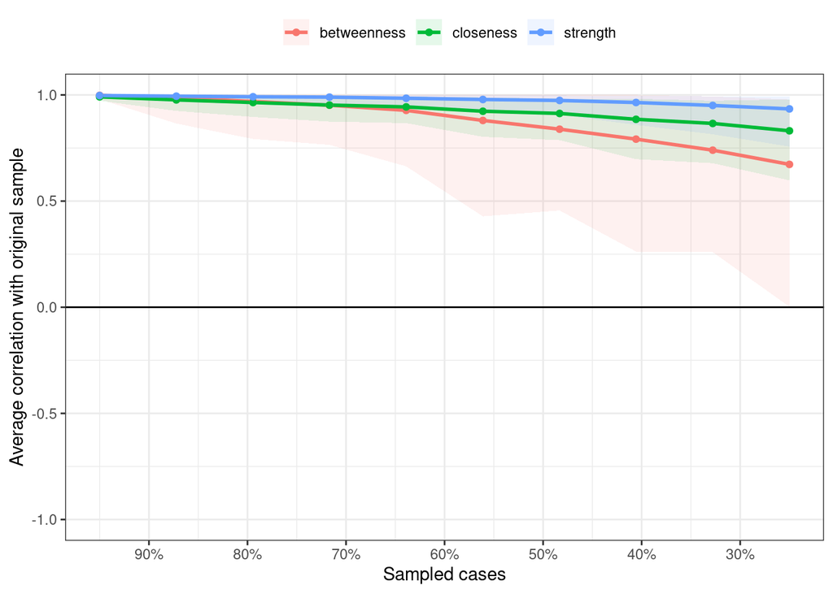

```r
plot(stability_centrality, c("strength", "closeness", "betweenness"))
```

```r
corStability(stability_centrality)
```

```
## === Correlation Stability Analysis ===
##
## Sampling levels tested:
##    nPerson Drop%   n
## 1      851  75.0 246
## 2     1116  67.2 254
## 3     1381  59.4 255
## 4     1645  51.7 245
## 5     1910  43.9 248
## 6     2175  36.1 240
## 7     2440  28.3 230
## 8     2704  20.6 253
## 9     2969  12.8 258
## 10    3234   5.0 271
##
## Maximum drop proportions to retain correlation of 0.7 in at least 95% of the samples:
##
## betweenness: 0.361
##   - For more accuracy, run bootnet(..., caseMin = 0.283, caseMax = 0.439)
##
## closeness: 0.672
##   - For more accuracy, run bootnet(..., caseMin = 0.594, caseMax = 0.75)
##
## strength: 0.75 (CS-coefficient is highest level tested)
##   - For more accuracy, run bootnet(..., caseMin = 0.672, caseMax = 1)
##
## Accuracy can also be increased by increasing both 'nBoots' and 'caseN'.
```

### 有意差検定

```r
differenceTest(accuracy_edge, 2, 6, "strength")
```

```
##     id1   id2  measure      lower      upper significant
## 1 gad7b gad7f strength -0.5858273 -0.4037575        TRUE
```

エッジ間の差の検定結果をプロットします。それぞれのエッジ間で有意な差がある場合は黒く塗りつぶされ，有意ではない場合は灰色に塗りつぶされます。

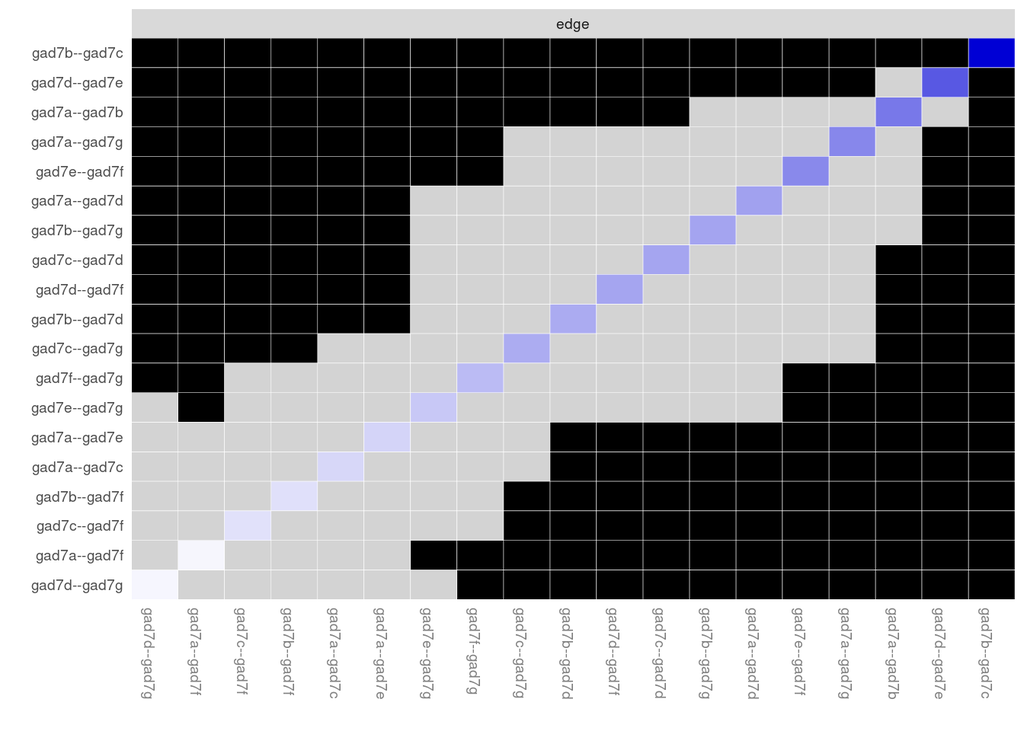

```r
plot(accuracy_edge, "edge", plot = "difference", onlyNonZero = TRUE, order = "sample")
```

各ノード間のStrengthの差の検定結果をプロットします。それぞれのエッジ間で有意な差がある場合は黒く塗りつぶされ，有意ではない場合は灰色に塗りつぶされます。

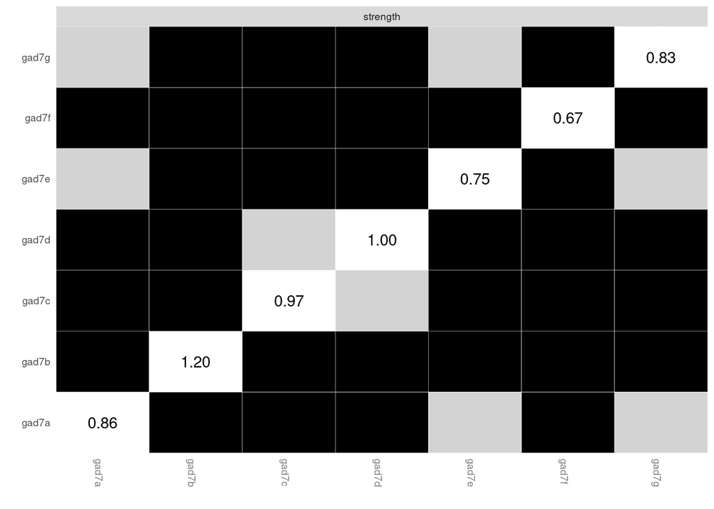

```r
plot(accuracy_edge,"strength")
```

### Isingモデル

PHQ9のデータは，bootnetパッケージのbinarize関数で２値化します(split=1なので，0は0,１以上が１に変換されます)。

```r
data_phq <- data %>%
  mutate(phq9a = S_PHQ9_a, phq9b = S_PHQ9_b,
         phq9c = S_PHQ9_c, phq9d = S_PHQ9_d,
         phq9e = S_PHQ9_e, phq9f = S_PHQ9_f,
         phq9g = S_PHQ9_g, phq9h = S_PHQ9_h,
         phq9i = S_PHQ9_i) %>%
  select(phq9a, phq9b, phq9c, phq9d, phq9e, phq9f, phq9g, phq9h, phq9i) %>%
  binarize(split = 1)
```

IsingSamplerを使って，IsingモデルでPHQ-9のネットワークを推定して，プロットします。

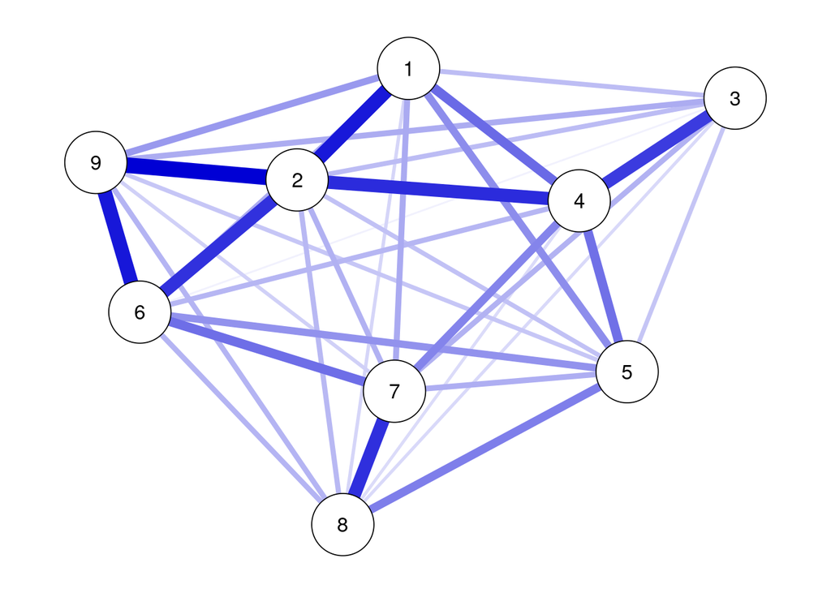

```r
results_phq <- estimateNetwork(data_phq,default = "IsingSampler", method = "uni")
plot(results_phq, theme = "colorblind", layout = "spring",labels = TRUE)
```

psychonetricsでもIsingモデルが扱えるようになっています（最尤推定）。

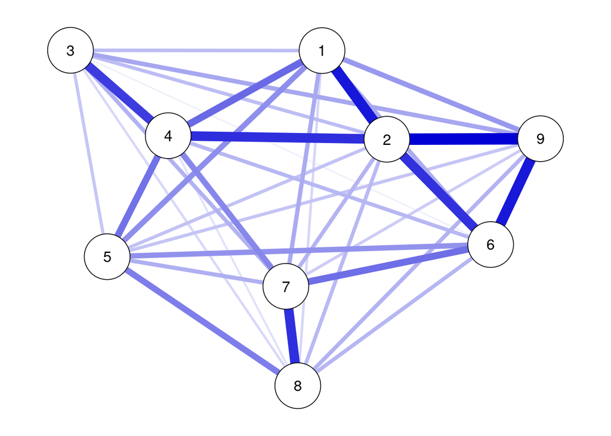

```r
Ising(data_phq) %>%
  runmodel %>%
  getmatrix("omega") %>%
  qgraph(theme = "colorblind", layout = "spring",labels = TRUE)
```

### MGMsモデル

2値データも連続データも扱えるMixed Graphical Models(MGMs)は，mgmパッケージで実行できる。異なる水準のデータを扱うため，以下の引数を設定する。

- type: p vector indicating the type of variable for each column in data. “g” for Gaussian, “p” for Poisson, “c” for categorical.
- level: p vector indicating the number of categories of each variable. For continuous variables set to 1.
- lambdaSel: Specifies the procedure for selecting the tuning parameter controlling the Lq-penalization. The two options are cross validation “CV” and the Extended Bayesian Information Criterion (EBIC) “EBIC”. The EBIC performs well in selecting sparse graphs (see Barber and Drton, 2010 and Foygel and Drton, 2014). Note that when also searching the alpha parameter in the elastic net penalty, cross validation should be preferred, as the parameter vector will not necessarily be sparse anymore. The EBIC tends to be a bit more conservative than CV (see Haslbeck and Waldorp, 2016). CV can sometimes not be performed with categorical variables, because glmnet requires at least 2 events of each category of each categorical variable in each training-fold. Defaults to lambdaSel = “CV”.
- lambdaFolds  
  Number of folds in cross validation if lambdaSel = “CV”.

データを準備します。

```r
data_na_omit <- na.omit(data)
data_gad_phq <- tibble(data_na_omit[,16:22],binarize(data_na_omit[,23:31], split = 1))

data_mgm <- data_gad_phq %>%
  rename(gad7a = S_GAD7_a, gad7b = S_GAD7_b,
         gad7c = S_GAD7_c, gad7d = S_GAD7_d,
         gad7e = S_GAD7_e, gad7f = S_GAD7_f,
         gad7g = S_GAD7_g, phq9a = S_PHQ9_a,
         phq9b = S_PHQ9_b, phq9c = S_PHQ9_c,
         phq9d = S_PHQ9_d, phq9e = S_PHQ9_e,
         phq9f = S_PHQ9_f, phq9g = S_PHQ9_g,
         phq9h = S_PHQ9_h, phq9i = S_PHQ9_i)
```

```r
data_mgm_type <- c(rep("g",7), rep("c",9))
data_mgm_level <- c(rep(1,7), rep(2,9))
data_mgm_label <- c("GAD1","GAD2","GAD3","GAD4","GAD5","GAD6","GAD7",
                    "PHQ1","PHQ2","PHQ3","PHQ4","PHQ5","PHQ6","PHQ7",
                    "PHQ8","PHQ9")
```

MGMsを実行します。

```r
library(mgm)
result_mgm <- mgm(data = data_mgm,
                  type = data_mgm_type,
                  level = data_mgm_level,
                  lambdaSel = "CV",
                  lambdaFolds = 10)
```

```
##
## Note that the sign of parameter estimates is stored separately; see ?mgm
```

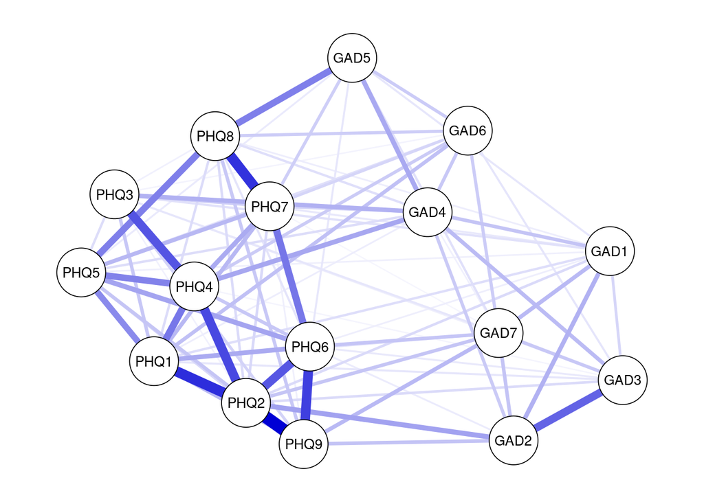

```r
qgraph(result_mgm$pairwise$wadj, theme = "colorblind", layout = "spring",labels = data_mgm_label)
```

## おわりに

心理ネットワークでの解析を概観してきましたが，心理ネットワーク分析手法は日進月歩です。どんどん新しい手法が提案されている現状がありますので，[Psych Systems](http://psychosystems.org/)のサイトを確認したり，そこで紹介されているサマースクールやワークショップに参加するのも良いかと思います。

## 文献

- Epskamp, S., Borsboom, D., & Fried, E. I. (2018). Estimating psychological networks and their accuracy: A tutorial paper. Behavior Research Methods, 50(1), 195–212.
- Epskamp, S., Waldorp, L. J., Mõttus, R., & Borsboom, D. (2018). The Gaussian Graphical Model in Cross-Sectional and Time-Series Data. Multivariate Behavioral Research, 53(4), 453–480.
- Epskamp, S., Maris, G., Waldorp, L. J., & Borsboom, D. (2018). Network Psychometrics. In The Wiley Handbook of Psychometric Testing (pp. 953–986). John Wiley & Sons, Ltd.
- Isvoranu, A., Epskamp, S., Waldorp, L., & Borsboom, D.(2022) Network Psychometrics with R. Taylor and Francis.
- Jones, P. J., Ma, R., & McNally, R. J. (2021). Bridge Centrality: A Network Approach to Understanding Comorbidity. Multivariate Behavioral Research, 56(2), 353–367.
- Jordan, P., Shedden-Mora, M. C., & Löwe, B. (2017). Psychometric analysis of the Generalized Anxiety Disorder scale (GAD-7) in primary care using modern item response theory. PloS One, 12(8), e0182162.